# Your Digest for Monday, Dec 04, 2023 11:59 PM

# Osteomalacia

## Clinical aspects

- Commonest cause is dietary vitamin D deficiency.
- The prevalence of vitamin D deficiency is **particularly high in older adults**,
  - Caused by age-associated ⬇ in *cutaneous* vitamin D production, ⬇ *dietary* vitamin D intake, and age-dependent *intestinal resistance* to calcitriol.
- **Symptoms**:
  - Bone pain + tenderness, Muscle *weakness*,
- **Imaging**: Reduced bone mineral density. Severe form -> "cod fish" concave vertebrae. **Looser zones** - insufficiency fractures seen as radiolucent areas in bone seen mostly in femoral neck, femoral shaft and pubic and ischial rami.

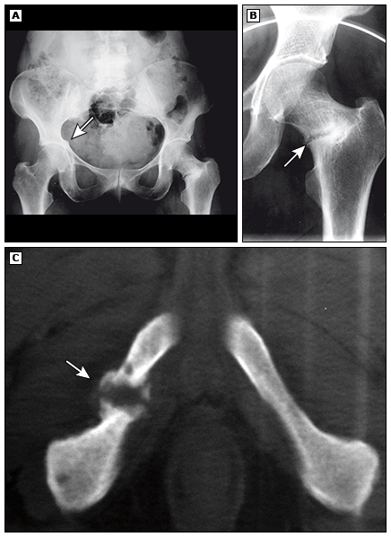

- **Labs**: ⬇ Ca2+, ⬇ PO43-, ⬇Vitamin D, **⬆** Alkaline phosphatase.
  - Tetracycline stains bands of osteoid. Bands become closer together and wider in osteomalacia.
- **Treatment**: 25,000 units once / week for 6 weeks followed by maintenance dose of 600 / week, Calcium supplementation
- **Expected outcome**: Dramatic improvement of symptoms within a few weeks.

## Basic Sciences

See [[Calcium Metabolism and Disorders.canvas|Calcium Metabolism and Disorders]]  
[[Hormone Physiology#Vitamin D]]

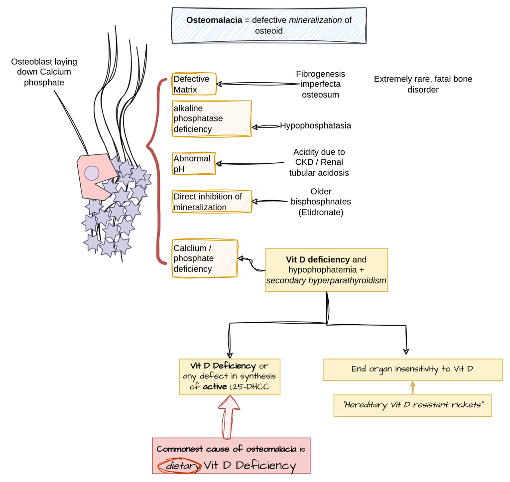

Activated vitamin D (1,25 dihydroxyvitamin D) regulates gene transcription by binding to intracellular receptors.  
Mechanism: dihydroxycholecalciferol binds to it's receptor and acts as a transcription regulator which increases **calbindin D** proteins.  
Calbindin increases intestinal calcium absorption.  
Induction of another protein in the renal tubules increases renal calcium absorption.  
Induction of **TRVP5** in the **proximal convoluted tubules** increases renal calcium absorption.

> [!INFO] FGF23 requires 'Klotho' to function.  
> Loss of function mutations of Klotho or FGF23 cause similar phenotypes of increased ageing and shorter lifespan, hyperphophatemia, and increased vitamin D3 level

Main action is to 'mobilize calcium from bone' and increase renal phosphate excretion.  
In hypoparathyroidism, there is **increased** bone minieral density. But the bone is not properly formed.  
So there are **increased fractures**  
Caused by a **defect in PTH receptor**  
Biochemical manifestations are just like hypoparathyroidism (Low Ca2+ and high Phosphate)  
**BUT** having **HIGH PTH level**  
Patients have **albright phenotype**

> In patients with hyperphosphataemia, there is indeed deposition of calcium phosphate. (*familial tumoural calcinosis*)  
> + Reabsorption is reduced by PTH;  
> ∴ ⬆ PTH → ↓Phosphate  
> + **FGF23** is the *earliest marker of abnormal phosphate handling in CKD*

## Hyperthyroidism

### Management of hyperthyroidism

*Methimazole* is *active metabolite* of carbimazole; Equivalent dose of *carbimazole is 40% higher*.

> [!INFO] Central molecules in the pathogensis are TNF and IL-1  
> These are blocked by biologic DMARDs

[output not shown]

As seen from EULAR diagnostic criteria, small joint involvement is more suggestive of RA than large joint involvement; but large join monoarthritis is not uncommmon. (knee or shoulder)

## Management of RA

- Options
  - Non-pharmacologic
  - Pharmacologic
  - Surgical - Synovectomy / tenosynovectomy / tendon realignment etc. / arthrodesis
- Phamacological : biologics are more effective than non biologics.
- DMARD induced immunosuppresion is a problem so that vaccine administration must be coordinated.
- Early use of DMARDS provides the greatest benefit so start them within 6 months of symptom onset.
- DMARDS take time to act so bridging therapy is needed with NSAIDS or ?corticosteroids.
- Non Biologics:
  - MTX and SSZ are the quickest and have the best risk:benefit ratios.
  - MTX is the standard of care for mod / severe RA.
  - Leflunamide is a new NB-DMARD; it's used when the patient has contraindications to MTX.
  - Injectable gold salts and penicillamine are not longer used because of poor effectiveness.
- Biologics:
  - Biologics retard joint destruction.
  - used as *second line after atleast* one NB is tried because of *cost* and lower rate of *induction of remission*.
  - Complications of treatment: immunosuppression (TB recurrence), drug induced lupus, formation of drug neutralizing antibodies. - *thoroughly screen latent TB* with IGRA or PPD testing.
  - **Anti-TNF**: Can cause TB and Hepatitis B reactivation; *concurrent use of live vaccines* is **contraindicated.**

### Antirheumatoid drugs

#### DMARDS

Beware of **fatal blood dyscrasias** and **cirrhosis**!!  
It is also an antifolate drug but this is not it's mechanism of anti rheumatoid action. (Therefore, folate is co administered). Antirheumatic action may be due to blockage of adenosine uptake.

- DMARDS are started early - that's the standard of care now.
- Method of treatment is "treat to target" - disease activity is assessed using DAS28CRP or DAS28ESR scores.